# Day 16: Pruning Trees — In-Class Activity (Solutions)

Is this college private? How many leaves should the tree have?

Instructor

```r
data(College)
College <- College %>%
  mutate(tuition = Outstate / 1000, undergrad = F.Undergrad / 1000)

# Day 14's folds (used in the Bonus)
set.seed(122)
College <- College %>%
  mutate(fold = sample(rep(1:5, length.out = n())))

# Day 15's settings for a tree grown until every leaf is pure
no_stopping <- rpart.control(cp = 0, minsplit = 2, minbucket = 1)
```

## Part 1: Grow Big, Then Cut Back

### Task 1.1: The pruning helper

```r
# Prune `tree` to the largest tree in its pruning sequence with at most
# `leaves` leaves
prune_to <- function(tree, leaves) {
  steps <- tree$cptable                          # one row per pruned tree
  row <- max(which(steps[, "nsplit"] + 1 <= leaves))
  prune(tree, cp = steps[row, "CP"])
}
```

### Task 1.2: Cut it back

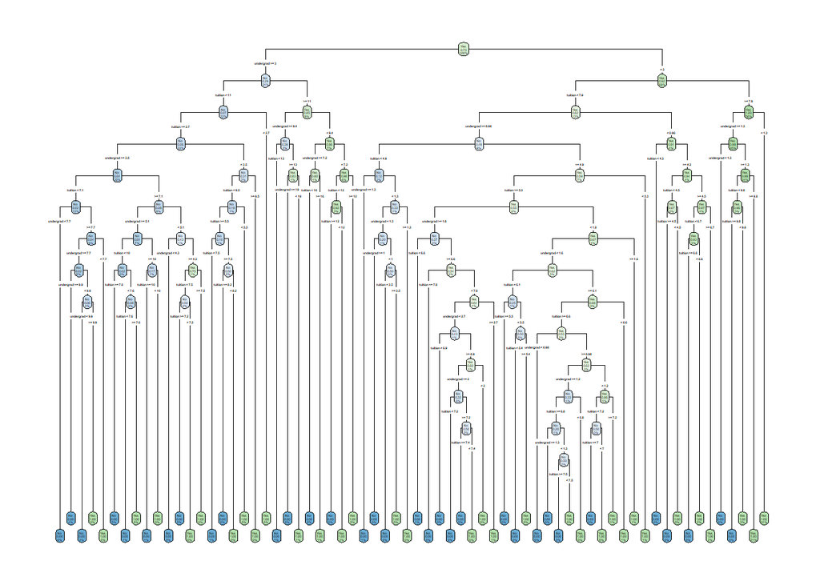

```r
set.seed(1)   # rpart runs its own CV while it grows the tree (Part 2)
full_tree <- rpart(Private ~ tuition + undergrad, data = College,
                   method = "class", control = no_stopping)
rpart.plot(full_tree, type = 4)   # the full tree, grown until every leaf is pure
```

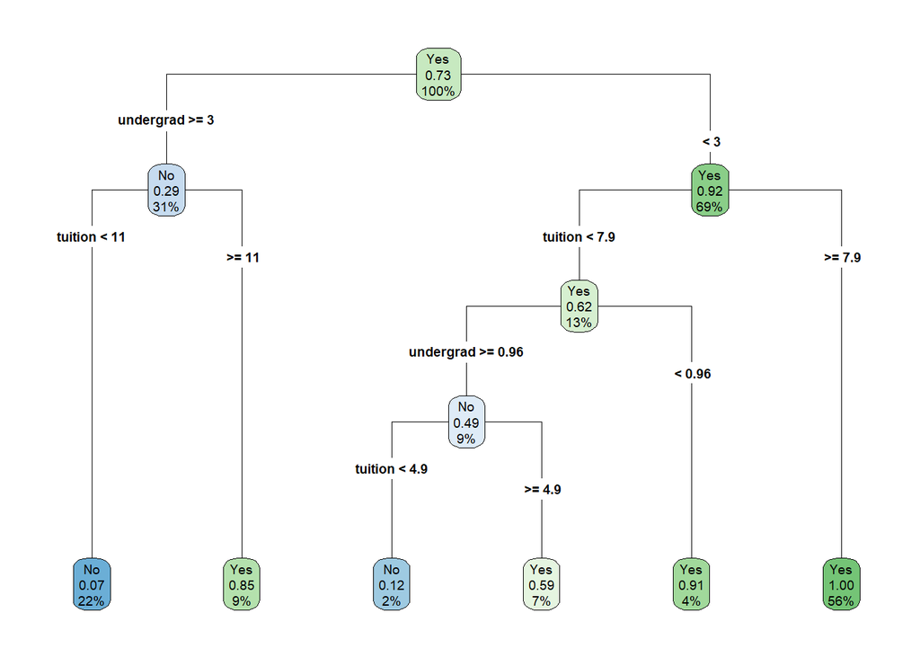

```r
tree6 <- prune_to(full_tree, 6)
rpart.plot(tree6, type = 4, extra = 106)
```

No: the full tree has 66 leaves, and most of its bottom splits isolate a handful of colleges; nobody could explain it, and its labels don’t even fit on the page. The 6-leaf tree fits in a sentence.

The full tree always wins on training error (here 0.0% vs 6.6% for 6 leaves), because every extra split can only fit the training colleges better, noise included. So training error would always pick the biggest tree, which Day 15 showed is not the best on new colleges. To choose a size we need error on colleges the tree didn’t see: CV.

## Part 2: Read `rpart`’s Table

```r
printcp(full_tree)
```

```
##
## Classification tree:
## rpart(formula = Private ~ tuition + undergrad, data = College,
##     method = "class", control = no_stopping)
##
## Variables actually used in tree construction:
## [1] tuition   undergrad
##
## Root node error: 212/777 = 0.27284
##
## n= 777
##
##           CP nsplit rel error  xerror     xstd
## 1  0.4764151      0  1.000000 1.00000 0.058566
## 2  0.2264151      1  0.523585 0.55660 0.047189
## 3  0.0188679      2  0.297170 0.35849 0.039059
## 4  0.0165094      5  0.240566 0.34434 0.038362
## 5  0.0117925      7  0.207547 0.33491 0.037887
## 6  0.0070755      9  0.183962 0.29717 0.035890
## 7  0.0047170     11  0.169811 0.28302 0.035099
## 8  0.0031447     26  0.094340 0.31604 0.036908
## 9  0.0023585     29  0.084906 0.31604 0.036908
## 10 0.0000000     65  0.000000 0.36792 0.039513
```

```r
cp_table <- as_tibble(full_tree$cptable)
root_err <- 212 / 777            # "Root node error" at the top of printcp

# 1. The nsplit = 2 row
row2 <- cp_table %>% filter(nsplit == 2)
row2$nsplit + 1                  # leaves
```

```
## [1] 3
```

```r
row2$`rel error` * root_err      # training error rate
```

```
## [1] 0.08108108
```

```r
# 2. From nsplit = 5 to nsplit = 7: rel error saved per split added
row5 <- cp_table %>% filter(nsplit == 5)
row7 <- cp_table %>% filter(nsplit == 7)
(row5$`rel error` - row7$`rel error`) / (row7$nsplit - row5$nsplit)
```

```
## [1] 0.01650943
```

```r
row5$CP
```

```
## [1] 0.01650943
```

```r
# 4. Where the default cp = 0.01 stops: the last row whose CP is at least 0.01
default_row <- cp_table %>% filter(CP >= 0.01) %>% slice_tail(n = 1)
default_row$nsplit + 1
```

```
## [1] 8
```

1. `nsplit = 2` means **3 leaves**. Its training error rate is 0.297 × 27.3% = **8.1%**.
2. Going from 6 to 8 leaves adds 2 splits, and `rel error` drops from 0.241 to 0.208: **0.017 per split**, the same as the `CP` in the `nsplit = 5` row (0.017). So a row’s `CP` is how much (relative) training error each split in the next step saves: the “price” those splits are worth.
3. No. `xerror` falls to 0.283 at 12 leaves, then rises again, to 0.368 for the full tree.
4. `cp = 0.01` keeps every step whose `CP` is at least 0.01, so it stops at **8 leaves** (`CP` = 0.012; the next step’s `CP` is below 0.01).

**In words:** `CP` is the training error a step’s splits save, per split, as a share of the root error. `rel error` is the tree’s training error as a share of the root error. `xerror` is the same thing measured by CV, on colleges each tree didn’t see. Training error can only fall as the tree grows, because every split fits the training colleges better. CV error falls while the splits find real patterns and rises once they start fitting noise (Day 9’s U-shape).

## Part 3: Pick and Draw the Tree

### Task 3.1: The one-SE rule

```r
best <- cp_table %>% slice_min(xerror, n = 1, with_ties = FALSE)
best
```

```
## # A tibble: 1 × 5
##        CP nsplit `rel error` xerror   xstd
##     <dbl>  <dbl>       <dbl>  <dbl>  <dbl>
## 1 0.00472     11       0.170  0.283 0.0351
```

```r
cutoff <- best$xerror + best$xstd
cutoff
```

```
## [1] 0.3181174
```

```r
one_se <- cp_table %>% filter(xerror <= cutoff) %>% slice_min(nsplit, n = 1)
one_se
```

```
## # A tibble: 1 × 5
##        CP nsplit `rel error` xerror   xstd
##     <dbl>  <dbl>       <dbl>  <dbl>  <dbl>
## 1 0.00708      9       0.184  0.297 0.0359
```

```r
one_se$xerror * root_err         # CV error rate of the one-SE tree
```

```
## [1] 0.08108108
```

The lowest `xerror` is **0.283** at **12 leaves** (`xstd` 0.035), so the cutoff is 0.318. The smallest tree at or below it has **10 leaves** (`xerror` 0.297). Its CV error rate is 0.297 × 27.3% = **8.1%**.

### Task 3.2: The final tree

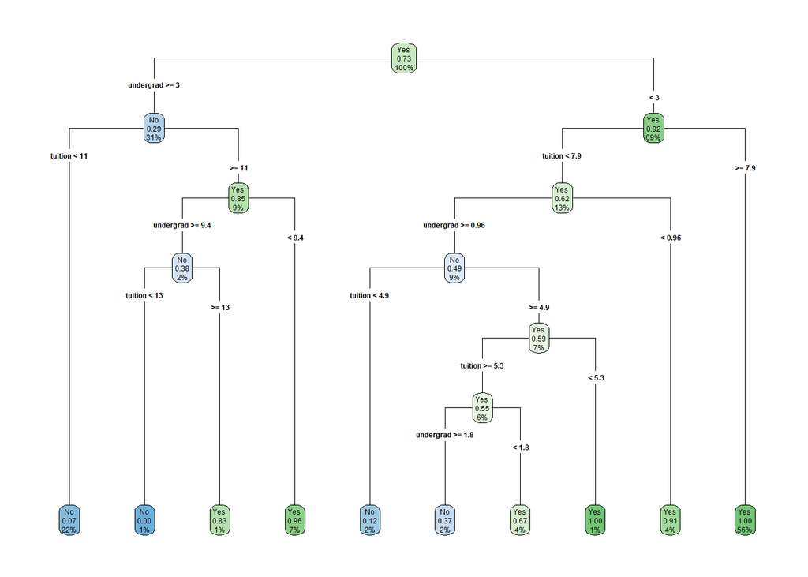

```r
final_tree <- prune_to(full_tree, one_se_leaves)
rpart.plot(final_tree, type = 4, extra = 106)
```

```r
claremont <- c("Claremont McKenna College", "Harvey Mudd College", "Pitzer College",
               "Scripps College")
College[claremont, c("Private", "tuition", "undergrad")]
```

```
##                           Private tuition undergrad
## Claremont McKenna College     Yes  17.000     0.887
## Harvey Mudd College           Yes  17.230     0.654
## Pitzer College                Yes  17.688     0.750
## Scripps College               Yes  17.238     0.569
```

**The Claremont Colleges:** all four have 569–887 undergrads (fewer than about 3,000) and tuition of $17,000–$17,688 (above about $7,900), so all four land in the same leaf: **432 small, expensive colleges**, 99.5% of which are private. The tree predicts private for all four (correct). They end up together because the tree only asks about size and tuition, and on both they look alike: small and expensive, the most clearly private corner of the data.

**Which to choose:** the tree’s CV error (8.1%) is worse than logistic regression (6.8%) and the best KNN (6.0%). (`rpart`’s CV uses 10 different folds, not Day 14’s, but the gap is larger than the SE.) If accuracy comes first, choose logistic regression; Day 14 called the logistic-vs-KNN gap borderline. The tree’s case is that anyone can follow it, as we just did for the Claremont Colleges: if the website needs to *show* its reasoning, a 10-leaf tree is easy to display.

## Bonus

### Bonus 1: Your own CV

```r
sizes <- c(1, 2, 3, 4, 6, 8, 12, 16, 24, 32, 48)
errors <- matrix(NA, nrow = length(sizes), ncol = 5)

for (f in 1:5) {
  train <- College %>% filter(fold != f)
  test  <- College %>% filter(fold == f)
  big <- rpart(Private ~ tuition + undergrad, data = train,
               method = "class", control = no_stopping)
  for (i in 1:length(sizes)) {
    pruned <- prune_to(big, sizes[i])
    pred <- predict(pruned, test, type = "class")
    errors[i, f] <- mean(pred != test$Private)
  }
}

cv_results <- tibble(size = sizes,
                     cv_error = rowMeans(errors),       # mean of each row
                     se = apply(errors, 1, sd) / sqrt(5))   # SE of each row's mean
cv_results
```

```
## # A tibble: 11 × 3
##     size cv_error      se
##    <dbl>    <dbl>   <dbl>
##  1     1   0.273  0.00885
##  2     2   0.165  0.0145
##  3     3   0.104  0.00860
##  4     4   0.0952 0.00379
##  5     6   0.0811 0.00769
##  6     8   0.0798 0.00772
##  7    12   0.0785 0.00464
##  8    16   0.0811 0.00593
##  9    24   0.0798 0.00664
## 10    32   0.0888 0.00475
## 11    48   0.0875 0.00442
```

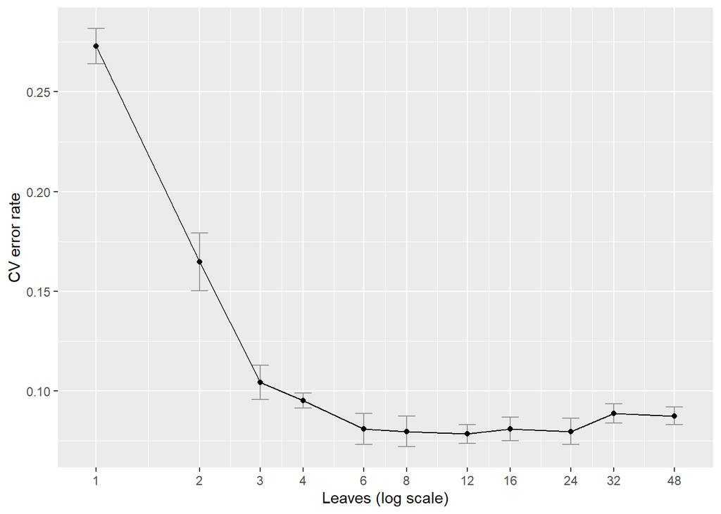

```r
ggplot(cv_results, aes(size, cv_error)) +
  geom_errorbar(aes(ymin = cv_error - se, ymax = cv_error + se),
                width = 0.05, color = "grey60") +
  geom_line() +
  geom_point() +
  scale_x_log10(breaks = sizes) +
  labs(x = "Leaves (log scale)", y = "CV error rate")
```

**Why a new tree in each fold:** `full_tree` was grown on all 777 colleges, including the ones in the test fold. Pruning it and testing on fold `f` would score the tree on colleges it already saw, the same mistake as scoring by training error. Growing the tree **and** pruning it have to happen on the training folds only. (`rpart` does the same thing inside `printcp`’s `xerror`.)

The loop’s lowest CV error is at **12 leaves** (7.8%), and the one-SE rule picks **6 leaves** (8.1%). `printcp()` picked 10 (8.1%). Close: the curve has a wide, flat bottom, so different folds settle on nearby sizes with about the same error.

### Bonus 2: Did pruning beat the default?

```r
errors_default <- rep(NA, 5)
for (f in 1:5) {
  train <- College %>% filter(fold != f)
  test  <- College %>% filter(fold == f)
  default_tree <- rpart(Private ~ tuition + undergrad, data = train, method = "class")
  pred <- predict(default_tree, test, type = "class")
  errors_default[f] <- mean(pred != test$Private)
}
mean(errors_default)
```

```
## [1] 0.08233251
```

On Day 14’s folds the default tree scores **8.2%** and the one-SE tree from Bonus 1 scores 8.1%: essentially a tie. In Part 2, `cp = 0.01` stopped at 8 leaves, right next to the one-SE size, inside the flat bottom of the CV curve. So for these colleges the default’s price per split happens to land on a good size. On the flood map, the small basins each saved less than 1% of the root error, so the default stopped well before the bottom of the curve. The default is a fixed guess; CV checks it on your data.

### Bonus 3: Another CV seed

```r
seeds_tab <- tibble()
for (s in c(1, 2, 3, 4, 5)) {
  set.seed(s)
  t <- rpart(Private ~ tuition + undergrad, data = College,
             method = "class", control = no_stopping)
  tab <- as_tibble(t$cptable)
  b <- tab %>% slice_min(xerror, n = 1, with_ties = FALSE)
  o <- tab %>% filter(xerror <= b$xerror + b$xstd) %>% slice_min(nsplit, n = 1)
  seeds_tab <- bind_rows(seeds_tab, tibble(seed = s, lowest = b$nsplit + 1, one_se = o$nsplit + 1))
}
seeds_tab
```

```
## # A tibble: 5 × 3
##    seed lowest one_se
##   <dbl>  <dbl>  <dbl>
## 1     1     12     10
## 2     2     27     10
## 3     3     10      8
## 4     4     10     10
## 5     5     10      6
```

The tree itself never changes (the seed only changes `rpart`’s CV folds), but the size with the lowest `xerror` moves (from 10 to 27 leaves) because the bottom of the curve is flat. The one-SE size moves less (6 to 10 leaves) and is never bigger. It’s the rule to trust: it doesn’t pretend to choose between sizes that CV can’t tell apart.

### Bonus 4: Many trees

```r
errors_bag <- rep(NA, 5)
set.seed(16)
for (f in 1:5) {
  train <- College %>% filter(fold != f)
  test  <- College %>% filter(fold == f)
  votes <- matrix(NA, nrow = nrow(test), ncol = 100)
  for (b in 1:100) {
    boot <- train %>% slice(sample(nrow(train), replace = TRUE))   # bootstrap sample
    big <- rpart(Private ~ tuition + undergrad, data = boot,
                 method = "class", control = no_stopping)
    votes[, b] <- predict(big, test, type = "class") == "Yes"
  }
  pred <- if_else(rowMeans(votes) > 0.5, "Yes", "No")
  errors_bag[f] <- mean(pred != test$Private)
}
mean(errors_bag)
```

```
## [1] 0.07076923
```

```r
sd(errors_bag) / sqrt(5)
```

```
## [1] 0.004912803
```

The vote scores **7.1%** (SE 0.5%), better than the pruned tree (8.1% on the same folds) and about the same as logistic regression (6.8%). Each full tree overfits in its own way, because each saw a different bootstrap sample. Their mistakes on a given college don’t all go the same way, so the majority vote cancels much of the noise (lower variance) while keeping the trees’ flexibility (low bias). This is **bagging**, Day 17’s topic.

### Bonus 5: All the predictors

```r
college_all <- College %>% select(-tuition, -undergrad)

set.seed(1)
full_all <- rpart(Private ~ . - fold, data = college_all, method = "class", control = no_stopping)
printcp(full_all)
```

```
##
## Classification tree:
## rpart(formula = Private ~ . - fold, data = college_all, method = "class",
##     control = no_stopping)
##
## Variables actually used in tree construction:
##  [1] Accept      Apps        Books       F.Undergrad Outstate    P.Undergrad
##  [7] perc.alumni Personal    PhD         Room.Board  Terminal    Top10perc
## [13] Top25perc
##
## Root node error: 212/777 = 0.27284
##
## n= 777
##
##           CP nsplit rel error  xerror     xstd
## 1  0.4764151      0  1.000000 1.00000 0.058566
## 2  0.2264151      1  0.523585 0.55660 0.047189
## 3  0.0235849      2  0.297170 0.35849 0.039059
## 4  0.0188679      5  0.226415 0.33019 0.037645
## 5  0.0157233      7  0.188679 0.33491 0.037887
## 6  0.0141509     10  0.141509 0.32075 0.037156
## 7  0.0094340     13  0.099057 0.32547 0.037402
## 8  0.0047170     15  0.080189 0.30660 0.036404
## 9  0.0023585     24  0.037736 0.30189 0.036148
## 10 0.0000000     39  0.000000 0.34434 0.038362
```

```r
tab_all <- as_tibble(full_all$cptable)
b_all <- tab_all %>% slice_min(xerror, n = 1, with_ties = FALSE)
one_se_all <- tab_all %>% filter(xerror <= b_all$xerror + b_all$xstd) %>% slice_min(nsplit, n = 1)
one_se_all$nsplit + 1
```

```
## [1] 6
```

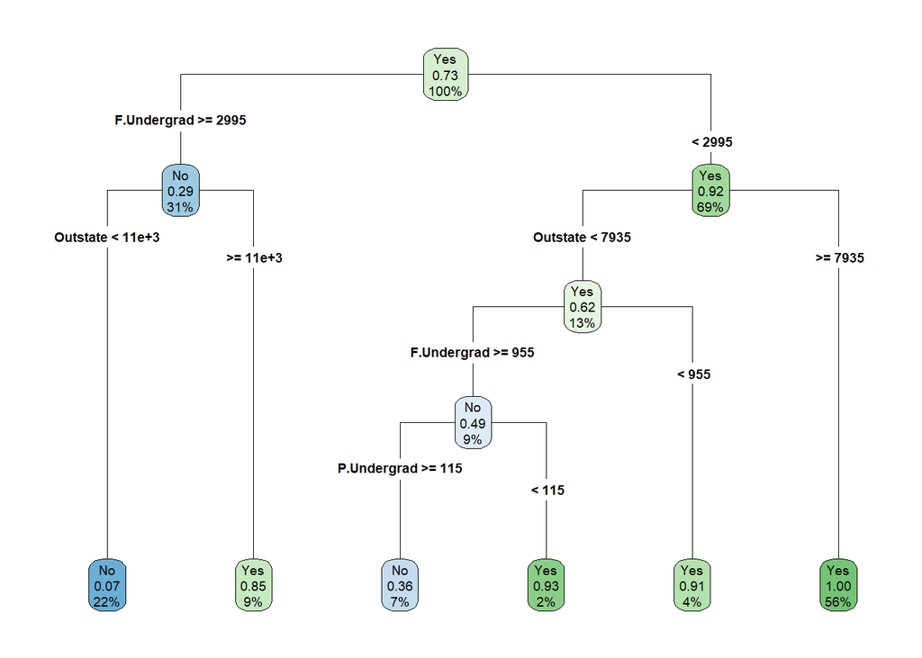

```r
final_all <- prune_to(full_all, one_se_all$nsplit + 1)
rpart.plot(final_all, type = 4, extra = 106)
```

The one-SE rule picks **6 leaves** (CV error 9.0%), using F.Undergrad, Outstate, P.Undergrad. The other predictors don’t earn a place in the pruned tree.